# project2b

Shaya Engelman

2023-10-11

This dataset was provided to me by David Greer and we worked together on this project. The data is a collection of terror attacks from 1970-2021 around the world broken down by attack method. For this project I wanted to summarise the terror attacks specifically in the Middle East and see the relative amounts between Middle Eastern countries.

First, I printed the head andplotted the global breakdown of different attack methods just to illustrate the contents of the dataframe.

```r
terror <- read.csv("https://raw.githubusercontent.com/Shayaeng/Data607/main/Project2/terrorist-attacks-by-method.csv")

head(terror)
```

```
##        Entity Code Year Terrorist.attacks.Unknown Terrorist.attacks.Hijacking
## 1 Afghanistan  AFG 1970                         0                           0
## 2 Afghanistan  AFG 1971                         0                           0
## 3 Afghanistan  AFG 1972                         0                           0
## 4 Afghanistan  AFG 1973                         1                           0
## 5 Afghanistan  AFG 1974                         0                           0
## 6 Afghanistan  AFG 1975                         0                           0
##   Terrorist.attacks.Hostage.Taking..Barricade.Incident.
## 1                                                     0
## 2                                                     0
## 3                                                     0
## 4                                                     0
## 5                                                     0
## 6                                                     0
##   Terrorist.attacks.Unarmed.Assault
```

[output cut: 27 more lines]

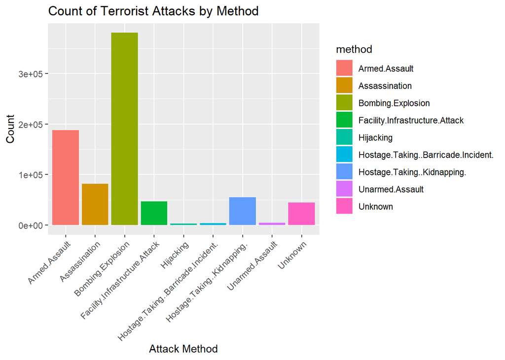

```r
method_columns <- colnames(terror)[grep("^Terrorist.attacks.", colnames(terror))]
cleaned_columns <- sub("^Terrorist.attacks.", "", method_columns)
colnames(terror)[grep("^Terrorist.attacks.", colnames(terror))] <- cleaned_columns
countries <- unique(terror$Entity)

terror_long <- pivot_longer(terror, cols = (all_of(cleaned_columns)), names_to = "method", values_to = "count")

ggplot(terror_long, aes(x = method, y = count, fill = method)) +
  geom_bar(stat = "identity") +
  labs(title = "Count of Terrorist Attacks by Method",
       x = "Attack Method",
       y = "Count") +
  theme(axis.text.x = element_text(angle = 45, hjust = 1))
```

```r
  scale_y_continuous(labels = scales::comma_format(scale = 1e-3))
```

```
## <ScaleContinuousPosition>
##  Range:
##  Limits:    0 --    1
```

According to the CIA, the countries in the following vector are in the Middle East. This can be found here https://www.cia.gov/the-world-factbook/middle-east/. I will create a subset dataframe containing the countries in the Middle East. After that I summarized the data by total amount of attacks over all years and plotted it.

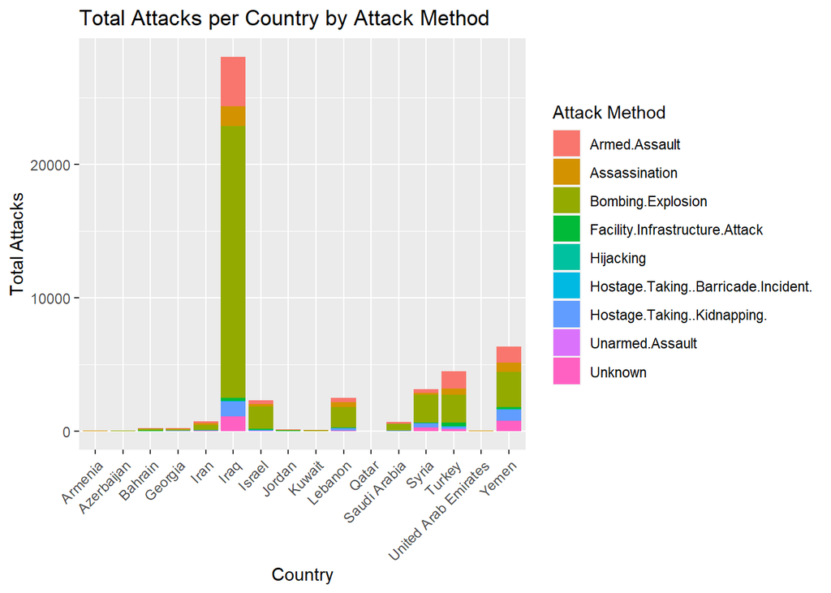

```r
middleEast <- c('Armenia','Azerbaijan','Bahrain','Gaza Strip','Georgia','Iran','Iraq','Israel','Jordan','Kuwait','Lebanon','Oman','Qatar','Saudi Arabia','Syria','Turkey','United Arab Emirates','West Bank','Yemen')

MEterror <- terror %>% filter(Entity %in% middleEast)

summary_data <- MEterror %>%
  group_by(Entity) %>%
  summarize(across(all_of(cleaned_columns), ~ sum(., na.rm = TRUE)))


summary_data_long <- summary_data %>%
  pivot_longer(cols = -Entity, names_to = "Attack_Method", values_to = "Total_Attacks")

ggplot(summary_data_long, aes(x = Entity, y = Total_Attacks, fill = Attack_Method)) +
  geom_bar(stat = "identity", position = "stack") +
  labs(title = "Total Attacks per Country by Attack Method",
       x = "Country",
       y = "Total Attacks",
       fill = "Attack Method") +
  theme(axis.text.x = element_text(angle = 45, hjust = 1))
```

The above plot doesn’t factor in the size of the country. To do that I added the 2023 population total and replotted the above as a ratio. Th population data was taken from here: https://www.census.gov/data-tools/demo/idb/

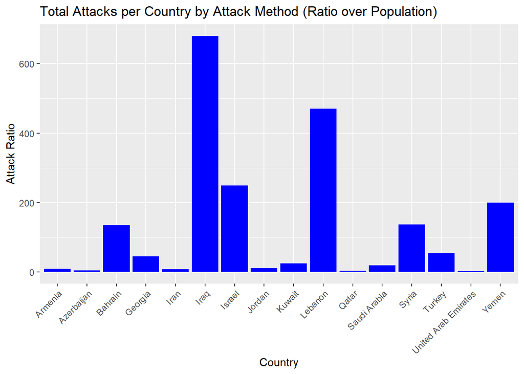

```r
me_population <- c(2.99, 10.6, 1.55, 2.1, 4.93, 87.59, 41.27, 9.26, 11.09, 3.1, 5.33, 3.83, 2.53, 35.94, 22.93, 83.59, 9.97, 3.18, 31.57)

population_df <- data.frame(middleEast, me_population)

summary_data <- summary_data %>%
  mutate(Total_Attacks = rowSums(select(., 2:10)))

summary_data <- left_join(summary_data, population_df, by = c("Entity" = "middleEast"))

summary_data$Attack_Ratio <- summary_data$Total_Attacks / summary_data$me_population

ggplot(summary_data, aes(x = Entity, y = Attack_Ratio)) +
  geom_bar(stat = "identity", position = "stack", fill = "blue") +
  labs(title = "Total Attacks per Country by Attack Method (Ratio over Population)",
       x = "Country",
       y = "Attack Ratio") +
  theme(axis.text.x = element_text(angle = 45, hjust = 1))
```

In the above plot we can see the unfortunate ratios of terror attacks per country in the Middle East.